# Inference for categorical data

## Getting Started

### Load packages

In this lab, we will explore and visualize the data using the **tidyverse** suite of packages, and perform statistical inference using **infer**. The data can be found in the companion package for OpenIntro resources, **openintro**.

Let’s load the packages.

```r
library(tidyverse)
library(openintro)
library(infer)
```

### The data

You will be analyzing the same dataset as in the previous lab, where you delved into a sample from the Youth Risk Behavior Surveillance System (YRBSS) survey, which uses data from high schoolers to help discover health patterns. The dataset is called `yrbss`.

1. What are the counts within each category for the amount of days these students have texted while driving within the past 30 days?

```r
data('yrbss', package='openintro')
yrbss %>%
  count(text_while_driving_30d)
```

```
## # A tibble: 9 × 2
##   text_while_driving_30d     n
##   <chr>                  <int>
## 1 0                       4792
## 2 1-2                      925
## 3 10-19                    373
## 4 20-29                    298
## 5 3-5                      493
## 6 30                       827
## 7 6-9                      311
## 8 did not drive           4646
## 9 <NA>                     918
```

The output above shows the counts for each category of `text_while_driving_30d`. The categories include 0, 1-2, 3-5, 6-9, 10-19, 20-29, and 30 days, along with `did not drive` and `NA` values. The largest group of respondents reported 0 days of texting while driving, while a smaller but notable number reported texting while driving all 30 days.

2. What is the proportion of people who have texted while driving every day in the past 30 days and never wear helmets?

```r
data('yrbss', package='openintro')
no_helmet <- yrbss %>%
  filter(helmet_12m == "never")

no_helmet <- no_helmet %>%
  mutate(text_ind = ifelse(text_while_driving_30d == "30", "yes", "no"))

no_helmet %>%
  drop_na(text_ind) %>%
  count(text_ind) %>%
  mutate(prop = n / sum(n))
```

```
## # A tibble: 2 × 3
##   text_ind     n   prop
##   <chr>    <int>  <dbl>
## 1 no        6040 0.929
## 2 yes        463 0.0712
```

The proportion of people who never wear helmets and have texted while driving every day in the past 30 days is approximately 0.0710 (about 7.1%).

## Inference on proportions

When summarizing the YRBSS, the Centers for Disease Control and Prevention seeks insight into the population *parameters*. To do this, you can answer the question, “What proportion of people in your sample reported that they have texted while driving each day for the past 30 days?” with a statistic; while the question “What proportion of people on earth have texted while driving each day for the past 30 days?” is answered with an estimate of the parameter.

The inferential tools for estimating population proportion are analogous to those used for means in the last chapter: the confidence interval and the hypothesis test.

```r
no_helmet %>%
  drop_na(text_ind) %>%
  specify(response = text_ind, success = "yes") %>%
  generate(reps = 1000, type = "bootstrap") %>%
  calculate(stat = "prop") %>%
  get_ci(level = 0.95)
```

```
## # A tibble: 1 × 2
##   lower_ci upper_ci
##      <dbl>    <dbl>
## 1   0.0649   0.0772
```

Note that since the goal is to construct an interval estimate for a proportion, it’s necessary to both include the `success` argument within `specify`, which accounts for the proportion of non-helmet wearers than have consistently texted while driving the past 30 days, in this example, and that `stat` within `calculate` is here “prop”, signaling that you are trying to do some sort of inference on a proportion.

3. What is the margin of error for the estimate of the proportion of non-helmet wearers that have texted while driving each day for the past 30 days based on this survey?

```r
ci <- no_helmet %>%
  drop_na(text_ind) %>%
  specify(response = text_ind, success = "yes") %>%
  generate(reps = 1000, type = "bootstrap") %>%
  calculate(stat = "prop") %>%
  get_ci(level = 0.95)

ci
```

```
## # A tibble: 1 × 2
##   lower_ci upper_ci
##      <dbl>    <dbl>
## 1   0.0650   0.0775
```

```r
me <- (ci$upper_ci - ci$lower_ci) / 2
me
```

```
## [1] 0.006227895
```

4. Using the `infer` package, calculate confidence intervals for two other categorical variables (you’ll need to decide which level to call “success”, and report the associated margins of error. Interpet the interval in context of the data. It may be helpful to create new data sets for each of the two countries first, and then use these data sets to construct the confidence intervals.

**Variable 1: Proportion of students who are physically active 7 days per week**

```r
yrbss <- yrbss %>%
  mutate(active_ind = ifelse(physically_active_7d == 7, "yes", "no"))

ci_active <- yrbss %>%
  drop_na(active_ind) %>%
  specify(response = active_ind, success = "yes") %>%
  generate(reps = 1000, type = "bootstrap") %>%
  calculate(stat = "prop") %>%
  get_ci(level = 0.95)

ci_active
```

```
## # A tibble: 1 × 2
##   lower_ci upper_ci
##      <dbl>    <dbl>
## 1    0.264    0.280
```

```r
me_active <- (ci_active$upper_ci - ci_active$lower_ci) / 2
me_active
```

```
## [1] 0.007776108
```

**Variable 2: Proportion of students who watch 5+ hours of TV per school day**

```r
yrbss <- yrbss %>%
  mutate(tv_ind = ifelse(hours_tv_per_school_day == "5+", "yes", "no"))

ci_tv <- yrbss %>%
  drop_na(tv_ind) %>%
  specify(response = tv_ind, success = "yes") %>%
  generate(reps = 1000, type = "bootstrap") %>%
  calculate(stat = "prop") %>%
  get_ci(level = 0.95)

ci_tv
```

```
## # A tibble: 1 × 2
##   lower_ci upper_ci
##      <dbl>    <dbl>
## 1    0.115    0.126
```

```r
me_tv <- (ci_tv$upper_ci - ci_tv$lower_ci) / 2
me_tv
```

```
## [1] 0.005587958
```

We are 95% confident that the true proportion of high school students who watch 5 or more hours of TV on a school night falls within this interval. The margin of error is approximately 0.005.

## How does the proportion affect the margin of error?

Imagine you’ve set out to survey 1000 people on two questions: are you at least 6-feet tall? and are you left-handed? Since both of these sample proportions were calculated from the same sample size, they should have the same margin of error, right? Wrong! While the margin of error does change with sample size, it is also affected by the proportion.

Think back to the formula for the standard error: $SE = \sqrt{p(1-p)/n}$. This is then used in the formula for the margin of error for a 95% confidence interval:

$$ME = 1.96\times SE = 1.96\times\sqrt{p(1-p)/n} \,.$$
Since the population proportion $p$ is in this $ME$ formula, it should make sense that the margin of error is in some way dependent on the population proportion. We can visualize this relationship by creating a plot of $ME$ vs. $p$.

Since sample size is irrelevant to this discussion, let’s just set it to some value ($n = 1000$) and use this value in the following calculations:

```r
n <- 1000
```

The first step is to make a variable `p` that is a sequence from 0 to 1 with each number incremented by 0.01. You can then create a variable of the margin of error (`me`) associated with each of these values of `p` using the familiar approximate formula ($ME = 2 \times SE$).

```r
p <- seq(from = 0, to = 1, by = 0.01)
me <- 2 * sqrt(p * (1 - p)/n)
```

Lastly, you can plot the two variables against each other to reveal their relationship. To do so, we need to first put these variables in a data frame that you can call in the `ggplot` function.

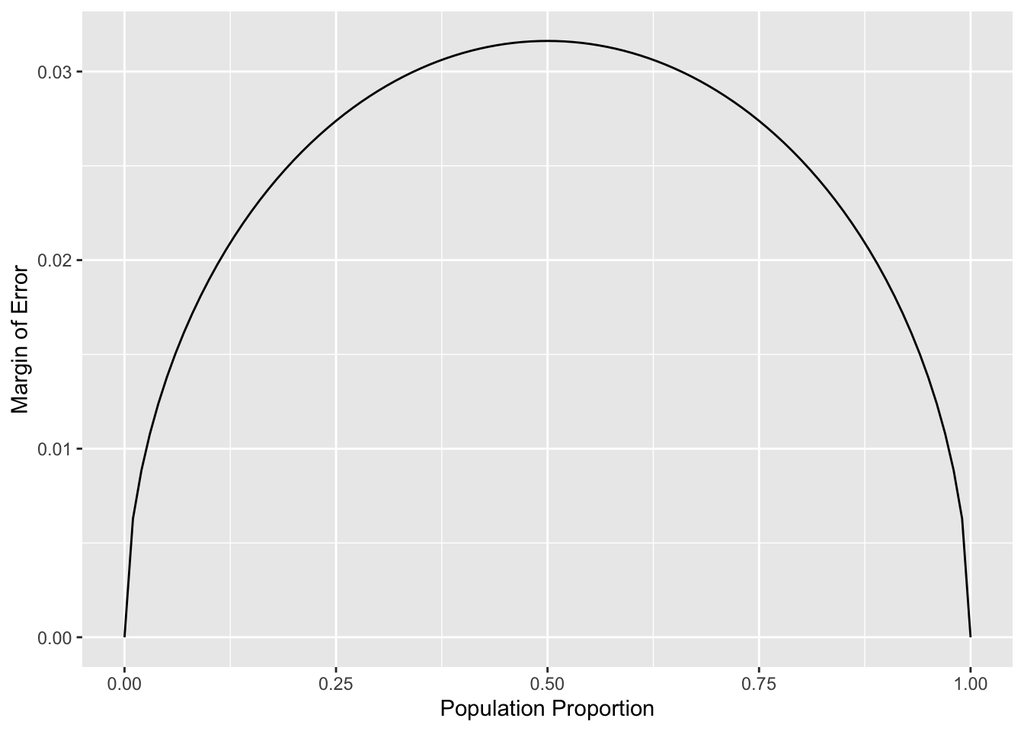

```r
dd <- data.frame(p = p, me = me)
ggplot(data = dd, aes(x = p, y = me)) +
  geom_line() +
  labs(x = "Population Proportion", y = "Margin of Error")
```

5. Describe the relationship between `p` and `me`. Include the margin of error vs. population proportion plot you constructed in your answer. For a given sample size, for which value of `p` is margin of error maximized?

The relationship between `p` and the margin of error follows a symmetric, concave-down (inverted U-shaped) curve. As `p` increases from 0, the margin of error increases, reaching its maximum at $p = 0.5$, and then decreases symmetrically as `p` approaches 1. This makes sense mathematically because the product $p(1-p)$ is maximized when $p = 0.5$. At the extremes ($p = 0$ or $p = 1$), the margin of error is 0 because there is no variability in the data. For a given sample size, **the margin of error is maximized when $p = 0.5$**, which is why $p = 0.5$ is used as the conservative estimate when the true proportion is unknown.

## Success-failure condition

We have emphasized that you must always check conditions before making inference. For inference on proportions, the sample proportion can be assumed to be nearly normal if it is based upon a random sample of independent observations and if both $np \geq 10$ and $n(1 - p) \geq 10$. This rule of thumb is easy enough to follow, but it makes you wonder: what’s so special about the number 10?

The short answer is: nothing. You could argue that you would be fine with 9 or that you really should be using 11. What is the “best” value for such a rule of thumb is, at least to some degree, arbitrary. However, when $np$ and $n(1-p)$ reaches 10 the sampling distribution is sufficiently normal to use confidence intervals and hypothesis tests that are based on that approximation.

6. Describe the sampling distribution of sample proportions at $n = 300$ and $p = 0.1$. Be sure to note the center, spread, and shape.

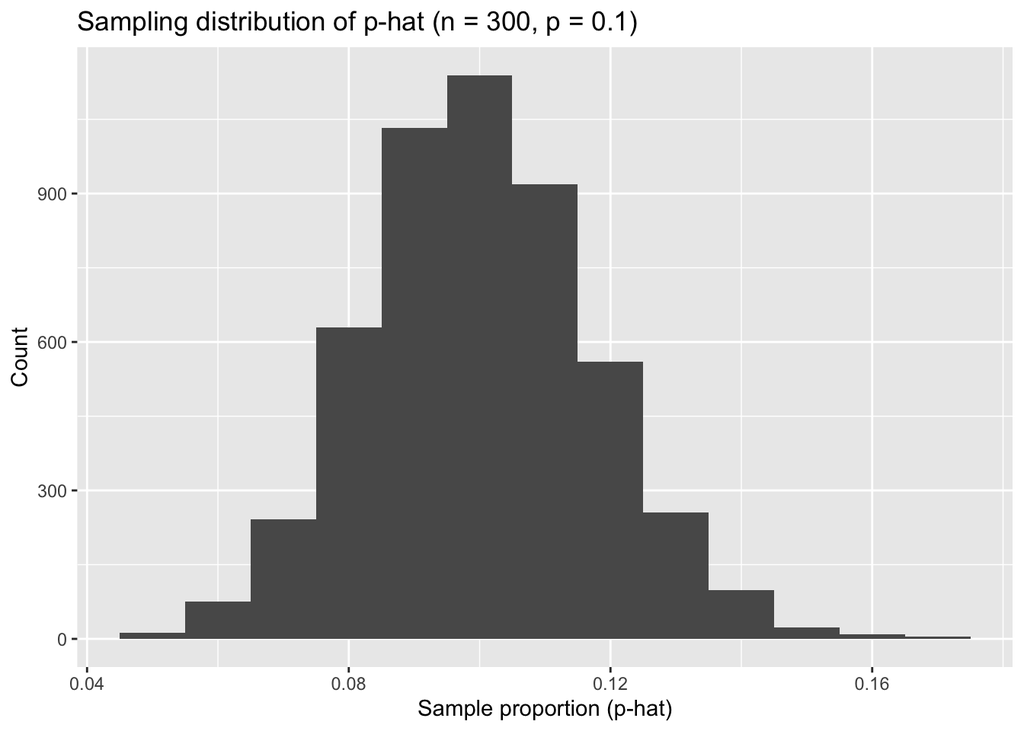

```r
set.seed(42)
sim_data <- data.frame(p_hat = rep(0, 5000))
for(i in 1:5000){
  samp <- sample(c(TRUE, FALSE), 300, replace = TRUE, prob = c(0.1, 0.9))
  sim_data$p_hat[i] <- sum(samp == TRUE) / 300
}

ggplot(data = sim_data, aes(x = p_hat)) +
  geom_histogram(binwidth = 0.01) +
  labs(title = "Sampling distribution of p-hat (n = 300, p = 0.1)",
       x = "Sample proportion (p-hat)", y = "Count")
```

```r
mean(sim_data$p_hat)
```

```
## [1] 0.1000987
```

```r
sd(sim_data$p_hat)
```

```
## [1] 0.01733338
```

At $n = 300$ and $p = 0.1$, the sampling distribution of sample proportions is approximately **normal** (bell-shaped), though with a very slight right skew. The **center** is at approximately 0.10, which matches the true population proportion $p$. The **spread** (standard deviation) is approximately $\sqrt{0.1 \times 0.9 / 300} \approx 0.0173$. The success-failure condition is satisfied since $np = 30 \geq 10$ and $n(1-p) = 270 \geq 10$, which is why the distribution looks approximately normal.

7. Keep $n$ constant and change $p$. How does the shape, center, and spread of the sampling distribution vary as $p$ changes. You might want to adjust min and max for the $x$-axis for a better view of the distribution.

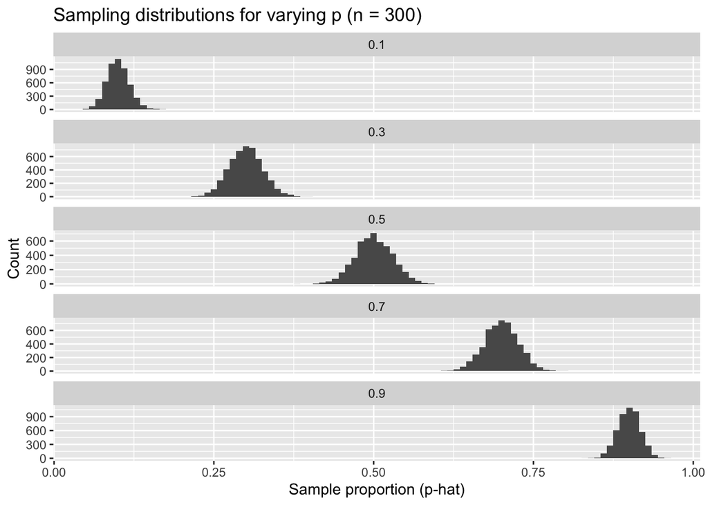

```r
set.seed(42)
p_vals <- c(0.1, 0.3, 0.5, 0.7, 0.9)
sim_vary_p <- data.frame()

for(p_val in p_vals) {
  p_hats <- replicate(5000, {
    samp <- sample(c(TRUE, FALSE), 300, replace = TRUE, prob = c(p_val, 1 - p_val))
    sum(samp == TRUE) / 300
  })
  sim_vary_p <- rbind(sim_vary_p, data.frame(p_hat = p_hats, p = as.factor(p_val)))
}

ggplot(data = sim_vary_p, aes(x = p_hat)) +
  geom_histogram(binwidth = 0.01) +
  facet_wrap(~ p, ncol = 1, scales = "free_y") +
  labs(title = "Sampling distributions for varying p (n = 300)",
       x = "Sample proportion (p-hat)", y = "Count")
```

As $p$ changes with $n$ held constant at 300:

- **Center**: The center of the distribution shifts to match the value of $p$. When $p = 0.3$, the distribution is centered at 0.3, and so on.
- **Shape**: The distribution is most symmetric (closest to a perfect normal bell shape) when $p = 0.5$. As $p$ moves toward 0 or 1, the distribution becomes slightly skewed – right-skewed when $p$ is small and left-skewed when $p$ is large.
- **Spread**: The spread is largest when $p = 0.5$ and smallest when $p$ is near 0 or 1. This is consistent with the formula $SE = \sqrt{p(1-p)/n}$, since $p(1-p)$ is maximized at $p = 0.5$.
8. Now also change $n$. How does $n$ appear to affect the distribution of $\hat{p}$?

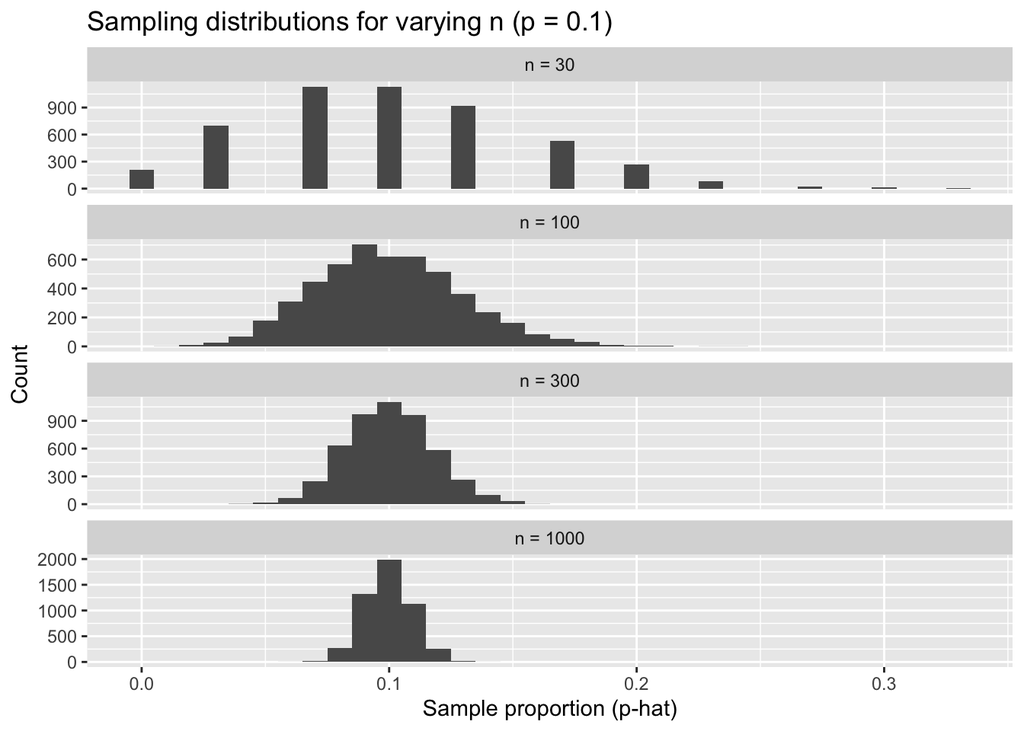

```r
set.seed(42)
n_vals <- c(30, 100, 300, 1000)
sim_vary_n <- data.frame()

for(n_val in n_vals) {
  p_hats <- replicate(5000, {
    samp <- sample(c(TRUE, FALSE), n_val, replace = TRUE, prob = c(0.1, 0.9))
    sum(samp == TRUE) / n_val
  })
  sim_vary_n <- rbind(sim_vary_n, data.frame(p_hat = p_hats,
                                              n = paste("n =", n_val)))
}

sim_vary_n$n <- factor(sim_vary_n$n, levels = paste("n =", n_vals))

ggplot(data = sim_vary_n, aes(x = p_hat)) +
  geom_histogram(binwidth = 0.01) +
  facet_wrap(~ n, ncol = 1, scales = "free_y") +
  labs(title = "Sampling distributions for varying n (p = 0.1)",
       x = "Sample proportion (p-hat)", y = "Count")
```

As $n$ increases:

- **Center**: The center stays at $p = 0.1$ regardless of sample size, which makes sense since $\hat{p}$ is an unbiased estimator.
- **Spread**: The spread decreases as $n$ increases. This follows from $SE = \sqrt{p(1-p)/n}$ – as $n$ grows, the standard error shrinks, so the distribution becomes more tightly concentrated around $p$.
- **Shape**: The distribution becomes more normally distributed as $n$ increases. At small $n$ (e.g., $n = 30$), the distribution is noticeably right-skewed because $np = 3 < 10$ violates the success-failure condition. By $n = 300$, the distribution is approximately normal since both $np$ and $n(1-p)$ are well above 10.

## More Practice

For some of the exercises below, you will conduct inference comparing two proportions. In such cases, you have a response variable that is categorical, and an explanatory variable that is also categorical, and you are comparing the proportions of success of the response variable across the levels of the explanatory variable. This means that when using `infer`, you need to include both variables within `specify`.

9. Is there convincing evidence that those who sleep 10+ hours per day are more likely to strength train every day of the week? As always, write out the hypotheses for any tests you conduct and outline the status of the conditions for inference. If you find a significant difference, also quantify this difference with a confidence interval.

**Hypotheses:**

- $H_0$: There is no difference in the proportion who strength train every day between those who sleep 10+ hours and those who do not. $p_{10+} - p_{other} = 0$
- $H_A$: There is a difference in the proportion who strength train every day between those who sleep 10+ hours and those who do not. $p_{10+} - p_{other} \neq 0$

```r
yrbss <- yrbss %>%
  mutate(sleep_10plus = ifelse(school_night_hours_sleep == "10+", "yes", "no"),
         strength_daily = ifelse(strength_training_7d == 7, "yes", "no"))
```

```r
yrbss %>%
  drop_na(sleep_10plus, strength_daily) %>%
  count(sleep_10plus, strength_daily) %>%
  group_by(sleep_10plus) %>%
  mutate(prop = n / sum(n))
```

```
## # A tibble: 4 × 4
## # Groups:   sleep_10plus [2]
##   sleep_10plus strength_daily     n  prop
##   <chr>        <chr>          <int> <dbl>
## 1 no           no              9949 0.836
## 2 no           yes             1958 0.164
## 3 yes          no               228 0.731
## 4 yes          yes               84 0.269
```

```r
# Check success-failure condition
yrbss %>%
  drop_na(sleep_10plus, strength_daily) %>%
  count(sleep_10plus, strength_daily)
```

```
## # A tibble: 4 × 3
##   sleep_10plus strength_daily     n
##   <chr>        <chr>          <int>
## 1 no           no              9949
## 2 no           yes             1958
## 3 yes          no               228
## 4 yes          yes               84
```

**Conditions for inference:**

- **Independence**: The YRBSS is a survey of a large population and the sample is likely less than 10% of the total population, so the independence condition is reasonable. Within groups, observations are also independent.
- **Success-failure**: We need at least 10 successes and 10 failures in each group. Based on the counts above, both groups have well above 10 in each category, so this condition is met.

```r
set.seed(42)
obs_diff <- yrbss %>%
  drop_na(sleep_10plus, strength_daily) %>%
  specify(strength_daily ~ sleep_10plus, success = "yes") %>%
  calculate(stat = "diff in props", order = c("yes", "no"))

obs_diff
```

```
## Response: strength_daily (factor)
## Explanatory: sleep_10plus (factor)
## # A tibble: 1 × 1
##    stat
##   <dbl>
## 1 0.105
```

```r
null_dist <- yrbss %>%
  drop_na(sleep_10plus, strength_daily) %>%
  specify(strength_daily ~ sleep_10plus, success = "yes") %>%
  hypothesize(null = "independence") %>%
  generate(reps = 1000, type = "permute") %>%
  calculate(stat = "diff in props", order = c("yes", "no"))

get_p_value(null_dist, obs_stat = obs_diff, direction = "two-sided")
```

```
## # A tibble: 1 × 1
##   p_value
##     <dbl>
## 1       0
```

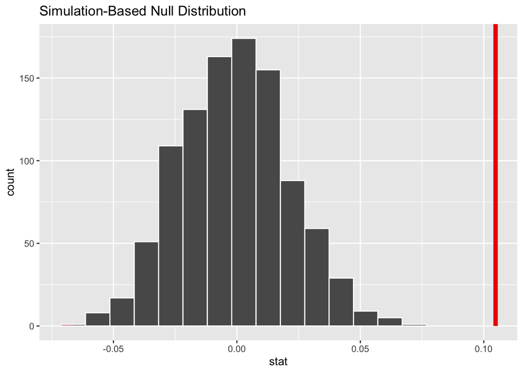

```r
visualize(null_dist) +
  shade_p_value(obs_stat = obs_diff, direction = "two-sided")
```

```r
# Confidence interval for the difference
set.seed(42)
boot_diff <- yrbss %>%
  drop_na(sleep_10plus, strength_daily) %>%
  specify(strength_daily ~ sleep_10plus, success = "yes") %>%
  generate(reps = 1000, type = "bootstrap") %>%
  calculate(stat = "diff in props", order = c("yes", "no"))

get_ci(boot_diff, level = 0.95)
```

```
## # A tibble: 1 × 2
##   lower_ci upper_ci
##      <dbl>    <dbl>
## 1   0.0562    0.153
```

**Conclusion:** The p-value from the hypothesis test will indicate whether there is statistically significant evidence of a difference. If the p-value is less than 0.05, we reject $H_0$ and conclude there is convincing evidence that the proportion who strength train daily differs between those who sleep 10+ hours and those who do not. The confidence interval for the difference in proportions quantifies the size of this difference. If the confidence interval does not contain 0, this is consistent with rejecting $H_0$.

10. Let’s say there has been no difference in likeliness to strength train every day of the week for those who sleep 10+ hours. What is the probablity that you could detect a change (at a significance level of 0.05) simply by chance? *Hint:* Review the definition of the Type 1 error.

A Type I error occurs when we reject a true null hypothesis. If there truly is no difference in the proportions (i.e., $H_0$ is true), then the probability of incorrectly rejecting $H_0$ is exactly the significance level $\alpha$. Since we are using a significance level of 0.05, the probability of detecting a change simply by chance is **0.05, or 5%**. This is the definition of a Type I error rate – it is the probability of finding a statistically significant result when there is actually no real effect.

11. Suppose you’re hired by the local government to estimate the proportion of residents that attend a religious service on a weekly basis. According to the guidelines, the estimate must have a margin of error no greater than 1% with 95% confidence. You have no idea what to expect for $p$. How many people would you have to sample to ensure that you are within the guidelines?  
    *Hint:* Refer to your plot of the relationship between $p$ and margin of error. This question does not require using a dataset.

Since we have no idea what $p$ is, we use the most conservative estimate $p = 0.5$, which (as shown in Exercise 5) maximizes the margin of error and therefore gives the largest required sample size.

Starting from the margin of error formula:

$$ME = 1.96 \times
\sqrt{\frac{p(1-p)}{n}}$$

We set $ME = 0.01$, $p = 0.5$, and solve for $n$:

$$0.01 = 1.96 \times \sqrt{\frac{0.5
\times 0.5}{n}}$$

$$\frac{0.01}{1.96} =
\sqrt{\frac{0.25}{n}}$$

$$\left(\frac{0.01}{1.96}\right)^2 =
\frac{0.25}{n}$$

$$n =
\frac{0.25}{\left(\frac{0.01}{1.96}\right)^2} = \frac{0.25 \times
1.96^2}{0.01^2}$$

```r
n_required <- 0.25 * 1.96^2 / 0.01^2
ceiling(n_required)
```

```
## [1] 9604
```

We would need to sample **at least 9,604 people** to ensure the margin of error is no greater than 1% with 95% confidence when using the conservative estimate of $p = 0.5$.